# Encounters QA Story Report

## What this is

> **Context & Scope** Scenario (public-safe)

> HarborPoint Health Plan receives weekly encounter batches from delegated vendors for multiple lines of business (e.g., Medicaid and Commercial). Before submitting these encounters to external reporting endpoints (state/federal programs), the Encounters team must catch blocking defects, prioritize remediation, and document a defensible audit trail.

> This evidence pack simulates that workflow end-to-end:
> - Row-level rejects (missing member/provider fields, invalid dates, eligibility outside coverage, duplicates, etc.)
> - Batch-level flags when operational thresholds are exceeded (duplicate rate >1%, eligibility mismatch >2%, volume shift >15%)
> - Ops decisions: Hold / Reprocess / Submit-with-monitoring
> - UAT traceability for upgrades and vendor feed changes

> Out of scope: This is not provider billing QA and not an EDI/837 parser; it's tabular pre-submit QA for payer encounter reporting. Hiring-manager readable summary of a 10-week encounters QA story.

The report is intentionally narrative-first:

- W02 blockers
- W06 eligibility incident + `R902`
- W07 duplicate incident + `R901` + monitor noise
- W10 volume anomaly + `R903` only

All non-incident weeks are shown as `CLEAN` in the storyboard.

## Explain It Like I'm A Hiring Manager

- **Encounter:** A record of care delivered to a member, used to support plan reporting and payment operations.
- **Batch:** A weekly package of encounter records sent together for preparation, validation, and submission.
- **Reject:** A record-level failure found during validation that must be fixed before clean submission.
- **Batch anomaly flag:** A batch-level warning when rates or volume are abnormal, even if not every record is rejected.
- **Triage summary:** A weekly rollup that shows issue volume by severity so operations teams can decide what to do first.
- **Preparation:** Assembling the encounter batch and checks needed before it can be submitted.
- **Validation and submission:** Running quality checks first, then sending only approved data.
- **Remediation and reprocessing:** Correcting root causes, rerunning the batch, and confirming the fixes hold.
- **Resubmit:** Sending the corrected batch after reprocessing and final review.
- **User Acceptance Testing (UAT):** Documented tests and evidence that prove the workflow and controls work as intended.

## Code Legend (Batch Flags)

| Code | Name | Threshold | Action |
| --- | --- | --- | --- |
| R901 | Duplicate-rate anomaly | Duplicate rate > 1% of claims in a batch | Remediate and reprocess before submission |
| R902 | Eligibility-mismatch anomaly | Eligibility mismatch rate > 2% of claims in a batch | Remediate and reprocess before submission |
| R903 | Volume-shift anomaly | Weekly volume shift > 15% vs trailing median | Submit with monitoring controls and follow-up |

> **How to interpret this report**
> 1. Start with the storyboard to see what happened each week.
> 2. Read the decision column to see operational action (hold, remediate/reprocess, or monitor).
> 3. Use the at-a-glance table for severity totals and top driver codes.
> 4. Use the incident drilldowns and UAT evidence to confirm traceable proof.

Storyboard (10-week timeline)

[output not shown]

Key Findings

- Total 10-week triage reject volume: **219** (**BLOCKER=80**, **HIGH=18**, **MONITOR=121**).

- Stable weeks are **CLEAN** (0 rejects): 2026-02-23, 2026-03-09, 2026-03-16, 2026-03-23, 2026-04-13, 2026-04-20.

- Four incidents are explicit in trend and storyboard: **W02 blockers**, **W06 eligibility + R902**, **W07 duplicates + R901 + monitors**, **W10 volume + R903 only**.

- Batch anomaly signals detected in-window: **R901=1**, **R902=1**, **R903=1**.

Story at a glance

|  | week_start | story_label | decision | blockers | high | monitor | top_driver_codes |
| --- | --- | --- | --- | --- | --- | --- | --- |
| 0 | 2026-02-23 | CLEAN | Monitor | 0 | 0 | 0 | (none) |
| 1 | 2026-03-02 | W02 BLOCKERS | Hold | 80 | 0 | 0 | FUTURE_SERVICE_DATE, NPI_BAD_LENGTH, NPI_NOT_FOUND |
| 2 | 2026-03-09 | CLEAN | Monitor | 0 | 0 | 0 | (none) |
| 3 | 2026-03-16 | CLEAN | Monitor | 0 | 0 | 0 | (none) |
| 4 | 2026-03-23 | CLEAN | Monitor | 0 | 0 | 0 | (none) |
| 5 | 2026-03-30 | W06 R902 ELIGIBILITY-MISMATCH ANOMALY (>2%) | Remediate | 0 | 7 | 0 | SERVICE_OUTSIDE_COVERAGE, ELIG_MISMATCH_GT_2PCT |
| 6 | 2026-04-06 | W07 R901 DUPLICATE-RATE ANOMALY (>1%) + MONITORS | Remediate | 0 | 11 | 120 | ALLOWED_GT_CHARGE, PAID_GT_ALLOWED, NULL_DX |
| 7 | 2026-04-13 | CLEAN | Monitor | 0 | 0 | 0 | (none) |
| 8 | 2026-04-20 | CLEAN | Monitor | 0 | 0 | 0 | (none) |
| 9 | 2026-04-27 | W10 R903 VOLUME-SHIFT ANOMALY (>15%) | Monitor | 0 | 0 | 1 | VOLUME_SHIFT_GT_15PCT |

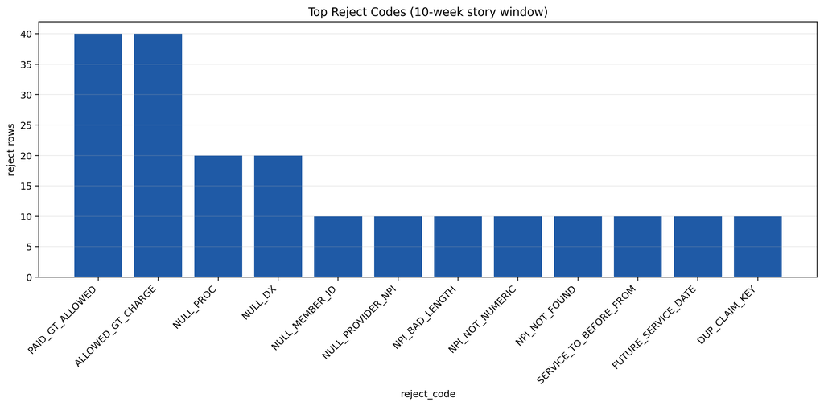

```
Visual QA PASS (Visual 1): bars=12, labels=12, size=142645 bytes
```

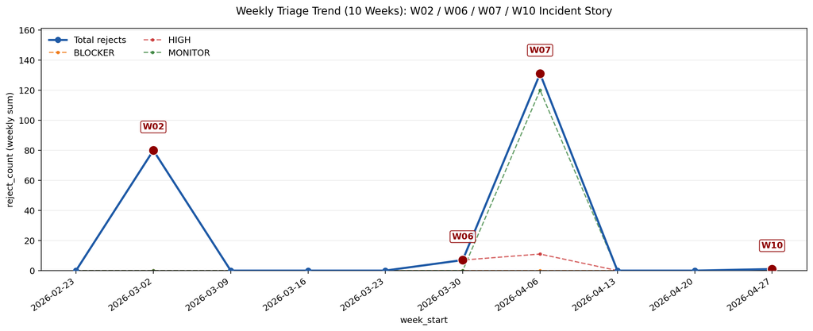

```
Visual QA PASS (Visual 2): size=180649 bytes
```

W02 incident: blockers

Triage rollup

|  | reject_category | severity | reject_count | affected_claims |
| --- | --- | --- | --- | --- |
| 0 | DATES | BLOCKER | 20 | 20 |
| 1 | PROVIDER | BLOCKER | 30 | 30 |
| 2 | REQUIRED_FIELD | BLOCKER | 30 | 25 |

Reject-code detail

|  | reject_code | rows |
| --- | --- | --- |
| 0 | NULL_MEMBER_ID | 10 |
| 1 | NULL_PROVIDER_NPI | 10 |
| 2 | NPI_BAD_LENGTH | 10 |
| 3 | NPI_NOT_NUMERIC | 10 |
| 4 | NPI_NOT_FOUND | 10 |
| 5 | SERVICE_TO_BEFORE_FROM | 10 |
| 6 | FUTURE_SERVICE_DATE | 10 |
| 7 | NULL_SERVICE_FROM | 5 |
| 8 | NULL_CLAIM_ID | 5 |

W06 incident: eligibility + R902

Triage rollup

|  | reject_category | severity | reject_count | affected_claims |
| --- | --- | --- | --- | --- |
| 3 | MEMBER_ELIGIBILITY | HIGH | 7 | 7 |

Reject-code detail

|  | reject_code | rows |
| --- | --- | --- |
| 0 | SERVICE_OUTSIDE_COVERAGE | 6 |
| 1 | ELIG_MISMATCH_GT_2PCT | 1 |

W07 incident: duplicates + R901 + monitors

Triage rollup

|  | reject_category | severity | reject_count | affected_claims |
| --- | --- | --- | --- | --- |
| 5 | DUPLICATE | HIGH | 11 | 11 |
| 4 | CODE_SET | MONITOR | 40 | 40 |
| 6 | FINANCIAL | MONITOR | 80 | 40 |

Reject-code detail

|  | reject_code | rows |
| --- | --- | --- |
| 0 | PAID_GT_ALLOWED | 40 |
| 1 | ALLOWED_GT_CHARGE | 40 |
| 2 | NULL_PROC | 20 |
| 3 | NULL_DX | 20 |
| 4 | DUP_CLAIM_KEY | 10 |
| 5 | DUP_RATE_GT_1PCT | 1 |

W10 incident: volume + R903 only

Triage rollup

|  | reject_category | severity | reject_count | affected_claims |
| --- | --- | --- | --- | --- |
| 7 | VOLUME_ANOMALY | MONITOR | 1 | 1 |

Reject-code detail

|  | reject_code | rows |
| --- | --- | --- |
| 0 | VOLUME_SHIFT_GT_15PCT | 1 |

Top Drivers by Week (triage_by_code)

|  | week_start | reject_code | reject_count |
| --- | --- | --- | --- |
| 0 | 2026-03-02 | FUTURE_SERVICE_DATE | 10 |
| 1 | 2026-03-02 | NPI_BAD_LENGTH | 10 |
| 2 | 2026-03-02 | NPI_NOT_FOUND | 10 |
| 3 | 2026-03-30 | SERVICE_OUTSIDE_COVERAGE | 6 |
| 4 | 2026-03-30 | ELIG_MISMATCH_GT_2PCT | 1 |
| 5 | 2026-04-06 | ALLOWED_GT_CHARGE | 40 |
| 6 | 2026-04-06 | PAID_GT_ALLOWED | 40 |
| 7 | 2026-04-06 | NULL_DX | 20 |
| 8 | 2026-04-27 | VOLUME_SHIFT_GT_15PCT | 1 |

```
Wrote docs/STORYBOARD.md
```